# rnaseqGene Notebook

# rnaseqGene workflow notebook

For this script to function properly, install the rnaseqGene package from bioconductor

```r
# For this script to function properly, install the rnaseqGene package from bioconductor using the commands directly below:
#if (!requireNamespace("BiocManager", quietly = TRUE))
#    install.packages("BiocManager")
#BiocManager::install("rnaseqGene", version = "3.8")
```

### Section 2.3: locating alignment files

```r
library(airway)
indir <- system.file("extdata", package="airway", mustWork=TRUE) # indir variable is just the name of a folder
indir # see?
```

```
[1] "/Library/Frameworks/R.framework/Versions/3.5/Resources/library/airway/extdata"
```

```r
list.files(indir) # shows us the files in that folder
```

```
 [1] "GSE52778_series_matrix.txt"        "Homo_sapiens.GRCh37.75_subset.gtf"
 [3] "sample_table.csv"                  "SraRunInfo_SRP033351.csv"
 [5] "SRR1039508_subset.bam"             "SRR1039509_subset.bam"
 [7] "SRR1039512_subset.bam"             "SRR1039513_subset.bam"
 [9] "SRR1039516_subset.bam"             "SRR1039517_subset.bam"
[11] "SRR1039520_subset.bam"             "SRR1039521_subset.bam"
```

```r
# importing the sample table into R
csvfile <- file.path(indir, "sample_table.csv")
sampleTable <- read.csv(csvfile, row.names = 1)
sampleTable
```

|  | SampleName | cell | dex | albut | Run | avgLength | Experiment | Sample | BioSample |
| --- | --- | --- | --- | --- | --- | --- | --- | --- | --- |
| SRR1039508 | GSM1275862 | N61311 | untrt | untrt | SRR1039508 | 126 | SRX384345 | SRS508568 | SAMN02422669 |
| SRR1039509 | GSM1275863 | N61311 | trt | untrt | SRR1039509 | 126 | SRX384346 | SRS508567 | SAMN02422675 |
| SRR1039512 | GSM1275866 | N052611 | untrt | untrt | SRR1039512 | 126 | SRX384349 | SRS508571 | SAMN02422678 |
| SRR1039513 | GSM1275867 | N052611 | trt | untrt | SRR1039513 | 87 | SRX384350 | SRS508572 | SAMN02422670 |
| SRR1039516 | GSM1275870 | N080611 | untrt | untrt | SRR1039516 | 120 | SRX384353 | SRS508575 | SAMN02422682 |
| SRR1039517 | GSM1275871 | N080611 | trt | untrt | SRR1039517 | 126 | SRX384354 | SRS508576 | SAMN02422673 |
| SRR1039520 | GSM1275874 | N061011 | untrt | untrt | SRR1039520 | 101 | SRX384357 | SRS508579 | SAMN02422683 |
| SRR1039521 | GSM1275875 | N061011 | trt | untrt | SRR1039521 | 98 | SRX384358 | SRS508580 | SAMN02422677 |

### Section 2.4: DESeq2 import functions

First, we need to import in the BAM files for our samples

```r
# import counts from BAM files
filenames <- file.path(indir, paste0(sampleTable$Run, "_subset.bam"))
file.exists(filenames)
```

```
[1] TRUE TRUE TRUE TRUE TRUE TRUE TRUE TRUE
```

```r
library("Rsamtools")
bamfiles <- BamFileList(filenames, yieldSize=2000000) # only import 2M seqs at a time
seqinfo(bamfiles[1])
```

```
Seqinfo object with 84 sequences from an unspecified genome:
```

|  | seqlengths | isCircular | genome |
| --- | --- | --- | --- |
| 1 | 249250621 | NA | NA |
| 10 | 135534747 | NA | NA |
| 11 | 135006516 | NA | NA |
| 12 | 133851895 | NA | NA |
| 13 | 115169878 | NA | NA |
| ... | ... | ... | ... |
| GL000210.1 | 27682 | NA | NA |
| GL000231.1 | 27386 | NA | NA |
| GL000229.1 | 19913 | NA | NA |
| GL000226.1 | 15008 | NA | NA |

[output cut: 1 more lines]

```
  NA
```

### Section 2.5: Defining gene models

To extract/summarize count info from the BAM files, we need annotations of where the genes and exons are, namely in GTF format.

```r
library("GenomicFeatures")
gtffile <- file.path(indir,"Homo_sapiens.GRCh37.75_subset.gtf")
txdb <- makeTxDbFromGFF(gtffile, format = "gtf", circ_seqs = character())
```

```
Import genomic features from the file as a GRanges object ... OK
Prepare the 'metadata' data frame ... OK
Make the TxDb object ... The "phase" metadata column contains non-NA values for features of type stop_codon.
  This information was ignored.OK
```

```r
txdb #transcript db
```

```
TxDb object:
# Db type: TxDb
# Supporting package: GenomicFeatures
# Data source: /Library/Frameworks/R.framework/Versions/3.5/Resources/library/airway/extdata/Homo_sapiens.GRCh37.75_subset.gtf
# Organism: NA
# Taxonomy ID: NA
# miRBase build ID: NA
# Genome: NA
# transcript_nrow: 65
# exon_nrow: 279
# cds_nrow: 158
# Db created by: GenomicFeatures package from Bioconductor
# Creation time: 2018-12-11 05:58:05 -0800 (Tue, 11 Dec 2018)
# GenomicFeatures version at creation time: 1.34.1
# RSQLite version at creation time: 2.1.1
# DBSCHEMAVERSION: 1.2
```

```r
ebg <- exonsBy(txdb, by="gene")
ebg # "exons by gene"
```

```
GRangesList object of length 20:
$ENSG00000009724
GRanges object with 18 ranges and 2 metadata columns:
       seqnames            ranges strand |   exon_id       exon_name
          <Rle>         <IRanges>  <Rle> | <integer>     <character>
   [1]        1 11086580-11087705      - |        98 ENSE00000818830
   [2]        1 11090233-11090307      - |        99 ENSE00000472123
   [3]        1 11090805-11090939      - |       100 ENSE00000743084
   [4]        1 11094885-11094963      - |       101 ENSE00000743085
   [5]        1 11097750-11097868      - |       102 ENSE00003482788
   ...      ...               ...    ... .       ...             ...
  [14]        1 11106948-11107176      - |       111 ENSE00003467404
  [15]        1 11106948-11107176      - |       112 ENSE00003489217
  [16]        1 11107260-11107280      - |       113 ENSE00001833377
  [17]        1 11107260-11107284      - |       114 ENSE00001472289
  [18]        1 11107260-11107290      - |       115 ENSE00001881401

...
<19 more elements>
-------
seqinfo: 1 sequence from an unspecified genome; no seqlengths
```

### Section 2.6: Read Counting & making a Summarized Experiment S4 object

```r
library("GenomicAlignments")
library("BiocParallel")
register(SerialParam()) # apparently, this drops us back down to 1 core use for the demo
#
# create the `se` summarized experiment object
se <- summarizeOverlaps(features=ebg, reads=bamfiles,
                        mode="Union",
                        singleEnd=FALSE,
                        ignore.strand=TRUE,
                        fragments=TRUE )
se
```

```
class: RangedSummarizedExperiment
dim: 20 8
metadata(0):
assays(1): counts
rownames(20): ENSG00000009724 ENSG00000116649 ... ENSG00000271794 ENSG00000271895
rowData names(0):
colnames(8): SRR1039508_subset.bam SRR1039509_subset.bam ... SRR1039520_subset.bam
  SRR1039521_subset.bam
colData names(0):
```

### Section 2.7: about the SummarizedExperiment object

```r
se
```

```
class: RangedSummarizedExperiment
dim: 20 8
metadata(0):
assays(1): counts
rownames(20): ENSG00000009724 ENSG00000116649 ... ENSG00000271794 ENSG00000271895
rowData names(0):
colnames(8): SRR1039508_subset.bam SRR1039509_subset.bam ... SRR1039520_subset.bam
  SRR1039521_subset.bam
colData names(0):
```

```r
dim(se)
```

```
[1] 20  8
```

```r
assayNames(se)
```

```
[1] "counts"
```

```r
head(assay(se), 3)
```

```
                SRR1039508_subset.bam SRR1039509_subset.bam SRR1039512_subset.bam
ENSG00000009724                    38                    28                    66
ENSG00000116649                  1004                  1255                  1122
ENSG00000120942                   218                   256                   233
                SRR1039513_subset.bam SRR1039516_subset.bam SRR1039517_subset.bam
ENSG00000009724                    24                    42                    41
ENSG00000116649                  1313                  1100                  1879
ENSG00000120942                   252                   269                   465
                SRR1039520_subset.bam SRR1039521_subset.bam
ENSG00000009724                    47                    36
ENSG00000116649                   745                  1536
ENSG00000120942                   207                   400
```

```r
colSums(assay(se))
```

```
SRR1039508_subset.bam SRR1039509_subset.bam SRR1039512_subset.bam SRR1039513_subset.bam
                 6478                  6501                  7699                  6801
SRR1039516_subset.bam SRR1039517_subset.bam SRR1039520_subset.bam SRR1039521_subset.bam
                 8009                 10849                  5254                  9168
```

```r
rowRanges(se)
```

```
GRangesList object of length 20:
$ENSG00000009724
GRanges object with 18 ranges and 2 metadata columns:
       seqnames            ranges strand |   exon_id       exon_name
          <Rle>         <IRanges>  <Rle> | <integer>     <character>
   [1]        1 11086580-11087705      - |        98 ENSE00000818830
   [2]        1 11090233-11090307      - |        99 ENSE00000472123
   [3]        1 11090805-11090939      - |       100 ENSE00000743084
   [4]        1 11094885-11094963      - |       101 ENSE00000743085
   [5]        1 11097750-11097868      - |       102 ENSE00003482788
   ...      ...               ...    ... .       ...             ...
  [14]        1 11106948-11107176      - |       111 ENSE00003467404
  [15]        1 11106948-11107176      - |       112 ENSE00003489217
  [16]        1 11107260-11107280      - |       113 ENSE00001833377
  [17]        1 11107260-11107284      - |       114 ENSE00001472289
  [18]        1 11107260-11107290      - |       115 ENSE00001881401

...
<19 more elements>
-------
seqinfo: 1 sequence from an unspecified genome; no seqlengths
```

```r
str(metadata(rowRanges(se))) # str is short for "internal STRucture"
```

```
List of 1
 $ genomeInfo:List of 15
  ..$ Db type                                 : chr "TxDb"
  ..$ Supporting package                      : chr "GenomicFeatures"
  ..$ Data source                             : chr "/Library/Frameworks/R.framework/Versions/3.5/Resources/library/airway/extdata/Homo_sapiens.GRCh37.75_subset.gtf"
  ..$ Organism                                : chr NA
  ..$ Taxonomy ID                             : chr NA
  ..$ miRBase build ID                        : chr NA
  ..$ Genome                                  : chr NA
  ..$ transcript_nrow                         : chr "65"
  ..$ exon_nrow                               : chr "279"
  ..$ cds_nrow                                : chr "158"
  ..$ Db created by                           : chr "GenomicFeatures package from Bioconductor"
  ..$ Creation time                           : chr "2018-12-11 05:58:05 -0800 (Tue, 11 Dec 2018)"
  ..$ GenomicFeatures version at creation time: chr "1.34.1"
  ..$ RSQLite version at creation time        : chr "2.1.1"
  ..$ DBSCHEMAVERSION                         : chr "1.2"
```

```r
### to view colData
colData(se) # no columns!
```

```
DataFrame with 8 rows and 0 columns
```

```r
### let's properly fill this slot
colData(se) <- DataFrame(sampleTable)
colData(se)
```

```
DataFrame with 8 rows and 9 columns
           SampleName     cell      dex    albut        Run avgLength Experiment    Sample
             <factor> <factor> <factor> <factor>   <factor> <integer>   <factor>  <factor>
SRR1039508 GSM1275862   N61311    untrt    untrt SRR1039508       126  SRX384345 SRS508568
SRR1039509 GSM1275863   N61311      trt    untrt SRR1039509       126  SRX384346 SRS508567
SRR1039512 GSM1275866  N052611    untrt    untrt SRR1039512       126  SRX384349 SRS508571
SRR1039513 GSM1275867  N052611      trt    untrt SRR1039513        87  SRX384350 SRS508572
SRR1039516 GSM1275870  N080611    untrt    untrt SRR1039516       120  SRX384353 SRS508575
SRR1039517 GSM1275871  N080611      trt    untrt SRR1039517       126  SRX384354 SRS508576
SRR1039520 GSM1275874  N061011    untrt    untrt SRR1039520       101  SRX384357 SRS508579
SRR1039521 GSM1275875  N061011      trt    untrt SRR1039521        98  SRX384358 SRS508580
              BioSample
               <factor>
SRR1039508 SAMN02422669
SRR1039509 SAMN02422675
SRR1039512 SAMN02422678
SRR1039513 SAMN02422670
SRR1039516 SAMN02422682
SRR1039517 SAMN02422673
SRR1039520 SAMN02422683
SRR1039521 SAMN02422677
```

## Section 3: The DESeqDataSet object, sample information and the design formula

```r
se$cell
```

```
[1] N61311  N61311  N052611 N052611 N080611 N080611 N061011 N061011
Levels: N052611 N061011 N080611 N61311
```

```r
se$dex
```

```
[1] untrt trt   untrt trt   untrt trt   untrt trt
Levels: trt untrt
```

```r
library("magrittr")
se$dex %<>% relevel("untrt")
se$dex
```

```
[1] untrt trt   untrt trt   untrt trt   untrt trt
Levels: untrt trt
```

```r
# this funny pipe that sends the changes back to the original object is equivalent to this:
# se$dex <- relevel(se$dex, "untrt")
```

### Section 3.1: Starting from a SummarizedExperiment

(yes, it over-writes our old `se` object. I don’t agree with this choice of just erasing the work we did before, but I’ll live with it.

```r
data("airway")
se <- airway
se$dex %<>% relevel("untrt")
se$dex
```

```
[1] untrt trt   untrt trt   untrt trt   untrt trt
Levels: untrt trt
```

```r
round( colSums(assay(se)) / 1e6, 1 )
```

```
SRR1039508 SRR1039509 SRR1039512 SRR1039513 SRR1039516 SRR1039517 SRR1039520 SRR1039521
      20.6       18.8       25.3       15.2       24.4       30.8       19.1       21.2
```

```r
colData(se)
```

```
DataFrame with 8 rows and 9 columns
           SampleName     cell      dex    albut        Run avgLength Experiment    Sample
             <factor> <factor> <factor> <factor>   <factor> <integer>   <factor>  <factor>
SRR1039508 GSM1275862   N61311    untrt    untrt SRR1039508       126  SRX384345 SRS508568
SRR1039509 GSM1275863   N61311      trt    untrt SRR1039509       126  SRX384346 SRS508567
SRR1039512 GSM1275866  N052611    untrt    untrt SRR1039512       126  SRX384349 SRS508571
SRR1039513 GSM1275867  N052611      trt    untrt SRR1039513        87  SRX384350 SRS508572
SRR1039516 GSM1275870  N080611    untrt    untrt SRR1039516       120  SRX384353 SRS508575
SRR1039517 GSM1275871  N080611      trt    untrt SRR1039517       126  SRX384354 SRS508576
SRR1039520 GSM1275874  N061011    untrt    untrt SRR1039520       101  SRX384357 SRS508579
SRR1039521 GSM1275875  N061011      trt    untrt SRR1039521        98  SRX384358 SRS508580
              BioSample
               <factor>
SRR1039508 SAMN02422669
SRR1039509 SAMN02422675
SRR1039512 SAMN02422678
SRR1039513 SAMN02422670
SRR1039516 SAMN02422682
SRR1039517 SAMN02422673
SRR1039520 SAMN02422683
SRR1039521 SAMN02422677
```

```r
# only putting this here because i've organized my chunks by section headers
library("DESeq2")
dds <- DESeqDataSet(se, design = ~ cell + dex)
```

### Section 3.2 Starting from count matrices

We’re going to skip 3.2 in class because it covers very similar steps to the first way we imported in data, and the main differences are that instead of importing from the BAMs, we would be running an outside counting tool that gave us a csv or tsv of counts, and building our S4 objects from that entry point.

## Section 4: Exploratory analysis and visualization

filtering, modeling variance examples, PCAs

### Section 4.1: Pre-filtering the dataset

```r
nrow(dds)
```

```
[1] 64102
```

```r
dds <- dds[ rowSums(counts(dds)) > 1, ]
nrow(dds)
```

```
[1] 29391
```

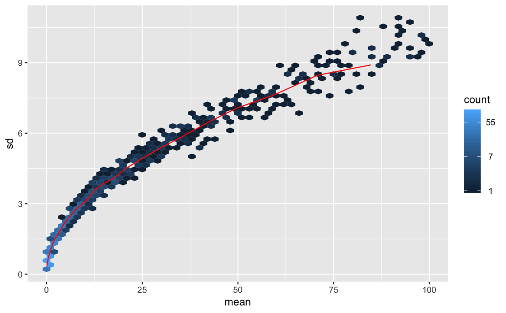

```r
lambda <- 10^seq(from = -1, to = 2, length = 1000)
cts <- matrix(rpois(1000*100, lambda), ncol = 100)
library("vsn")
# this install did not come with the workflow, but i bet they thought it would VVVVVV
# install.packages("hexbin")
library(hexbin)
meanSdPlot(cts, ranks = FALSE)
```

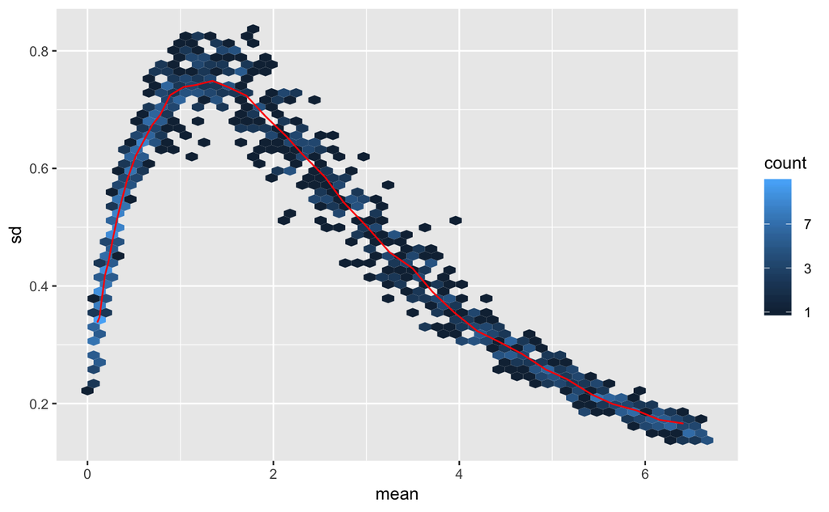

```r
log.cts.one <- log2(cts + 1)
meanSdPlot(log.cts.one, ranks = FALSE)
```

```r
vsd <- vst(dds, blind = FALSE)
head(assay(vsd), 3)
```

```
                SRR1039508 SRR1039509 SRR1039512 SRR1039513 SRR1039516 SRR1039517 SRR1039520
ENSG00000000003   9.742074   9.430420   9.867627   9.645845  10.183143   9.880416  10.010366
ENSG00000000419   9.333669   9.581707   9.486145   9.523093   9.427283   9.574860   9.325999
ENSG00000000457   8.765274   8.698449   8.651473   8.732426   8.592787   8.702674   8.761945
                SRR1039521
ENSG00000000003   9.639782
ENSG00000000419   9.509246
ENSG00000000457   8.724101
```

```r
colData(vsd)
```

```
DataFrame with 8 rows and 10 columns
           SampleName     cell      dex    albut        Run avgLength Experiment    Sample
             <factor> <factor> <factor> <factor>   <factor> <integer>   <factor>  <factor>
SRR1039508 GSM1275862   N61311    untrt    untrt SRR1039508       126  SRX384345 SRS508568
SRR1039509 GSM1275863   N61311      trt    untrt SRR1039509       126  SRX384346 SRS508567
SRR1039512 GSM1275866  N052611    untrt    untrt SRR1039512       126  SRX384349 SRS508571
SRR1039513 GSM1275867  N052611      trt    untrt SRR1039513        87  SRX384350 SRS508572
SRR1039516 GSM1275870  N080611    untrt    untrt SRR1039516       120  SRX384353 SRS508575
SRR1039517 GSM1275871  N080611      trt    untrt SRR1039517       126  SRX384354 SRS508576
SRR1039520 GSM1275874  N061011    untrt    untrt SRR1039520       101  SRX384357 SRS508579
SRR1039521 GSM1275875  N061011      trt    untrt SRR1039521        98  SRX384358 SRS508580
              BioSample        sizeFactor
               <factor>         <numeric>
SRR1039508 SAMN02422669  1.02364764926706
SRR1039509 SAMN02422675 0.896166721793923
SRR1039512 SAMN02422678  1.17948612081678
SRR1039513 SAMN02422670 0.670053829048202
SRR1039516 SAMN02422682  1.17767135405022
SRR1039517 SAMN02422673  1.39903646915342
SRR1039520 SAMN02422683 0.920778683328161
SRR1039521 SAMN02422677 0.944514089340919
```

```r
rld <- rlog(dds, blind = FALSE)
head(assay(rld), 3)
```

```
                SRR1039508 SRR1039509 SRR1039512 SRR1039513 SRR1039516 SRR1039517 SRR1039520
ENSG00000000003   9.385681   9.052599   9.516877   9.285335   9.839093   9.530313   9.663260
ENSG00000000419   8.869611   9.138274   9.036117   9.075296   8.972125   9.131828   8.861529
ENSG00000000457   7.961373   7.881385   7.824075   7.921493   7.751690   7.886441   7.957126
                SRR1039521
ENSG00000000003   9.277695
ENSG00000000419   9.060906
ENSG00000000457   7.912125
```

nrow(dds) [compare the presented filter with the one used in the BAD days Day 3 workflow](https://bitsandchips.me/BAD_days/RNA-sequencing.html#data-pre-processing)

### Section 4.2: The variance stabilizing transformation and the rlog

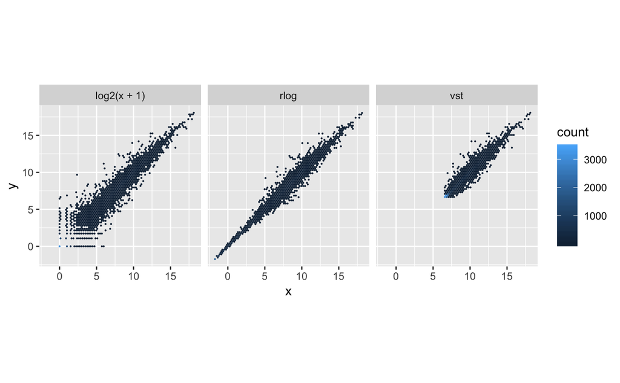

```r
library("dplyr")
library("ggplot2")
dds <- estimateSizeFactors(dds)
df <- bind_rows(
  as_data_frame(log2(counts(dds, normalized=TRUE)[, 1:2]+1)) %>%
         mutate(transformation = "log2(x + 1)"),
  as_data_frame(assay(vsd)[, 1:2]) %>% mutate(transformation = "vst"),
  as_data_frame(assay(rld)[, 1:2]) %>% mutate(transformation = "rlog"))

colnames(df)[1:2] <- c("x", "y")
ggplot(df, aes(x = x, y = y)) + geom_hex(bins = 80) +
  coord_fixed() + facet_grid( . ~ transformation)
```

### Section 4.3: Sample distances

```r
sampleDists <- dist(t(assay(vsd)))
sampleDists
```

```
           SRR1039508 SRR1039509 SRR1039512 SRR1039513 SRR1039516 SRR1039517 SRR1039520
SRR1039509   44.08478
SRR1039512   36.82952   51.50926
SRR1039513   59.23174   43.11327   47.21641
SRR1039516   41.08424   54.79377   40.18856   59.72262
SRR1039517   59.08409   47.46042   54.13979   46.36635   44.74738
SRR1039520   37.27578   54.00938   34.56797   55.44564   42.81024   58.22766
SRR1039521   59.26716   42.84573   54.13120   35.24746   60.64298   47.80456   48.24754
```

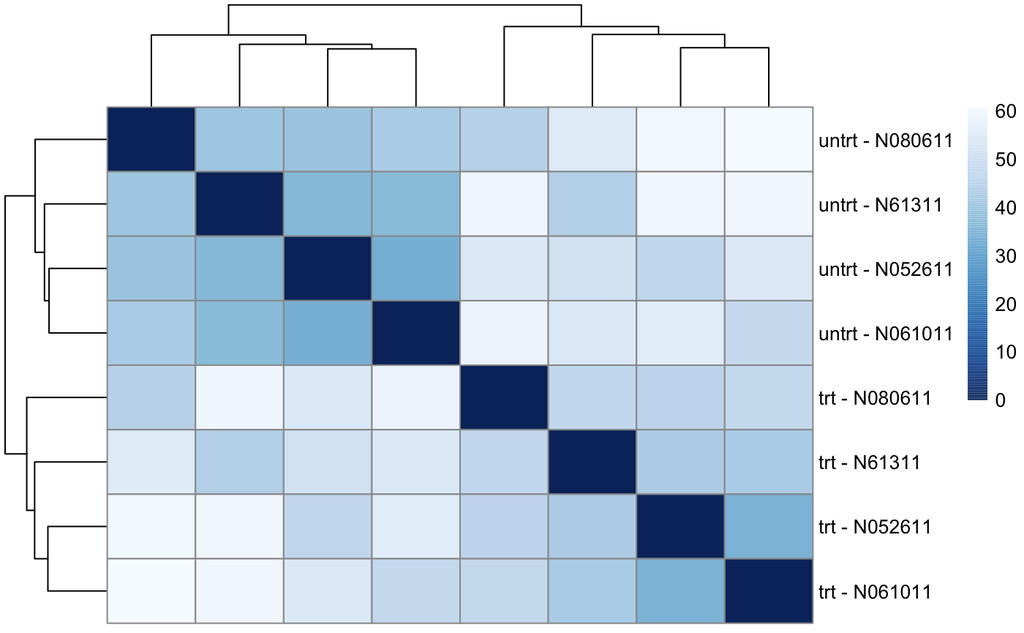

```r
library("pheatmap")
library("RColorBrewer")
sampleDistMatrix <- as.matrix( sampleDists )
rownames(sampleDistMatrix) <- paste( vsd$dex, vsd$cell, sep = " - " )
colnames(sampleDistMatrix) <- NULL
colors <- colorRampPalette( rev(brewer.pal(9, "Blues")) )(255)
pheatmap(sampleDistMatrix,
         clustering_distance_rows = sampleDists,
         clustering_distance_cols = sampleDists,
         col = colors)
```

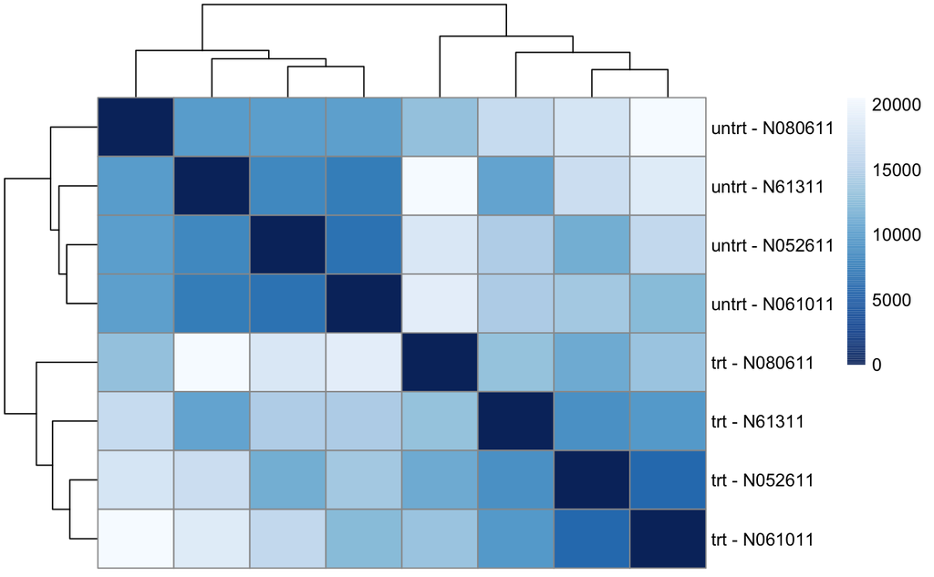

```r
library("PoiClaClu")
poisd <- PoissonDistance(t(counts(dds)))
samplePoisDistMatrix <- as.matrix( poisd$dd )
rownames(samplePoisDistMatrix) <- paste( dds$dex, dds$cell, sep=" - " )
colnames(samplePoisDistMatrix) <- NULL
pheatmap(samplePoisDistMatrix,
         clustering_distance_rows = poisd$dd,
         clustering_distance_cols = poisd$dd,
         col = colors)
```

### Section 4.4: PCA plot

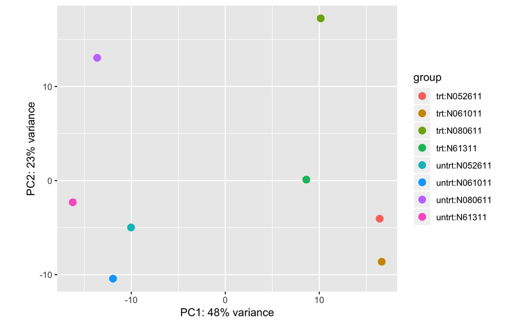

```r
plotPCA(vsd, intgroup = c("dex", "cell"))
```

```r
pcaData <- plotPCA(vsd, intgroup = c( "dex", "cell"), returnData = TRUE)
pcaData
```

|  | PC1 | PC2 | group | dex | cell | name |
| --- | --- | --- | --- | --- | --- | --- |
| SRR1039508 | -16.228435 | -2.3110688 | untrt:N61311 | untrt | N61311 | SRR1039508 |
| SRR1039509 | 8.618864 | 0.1055443 | trt:N61311 | trt | N61311 | SRR1039509 |
| SRR1039512 | -10.025968 | -4.9857836 | untrt:N052611 | untrt | N052611 | SRR1039512 |
| SRR1039513 | 16.424047 | -4.0524552 | trt:N052611 | trt | N052611 | SRR1039513 |
| SRR1039516 | -13.635225 | 13.0513834 | untrt:N080611 | untrt | N080611 | SRR1039516 |
| SRR1039517 | 10.153386 | 17.2437947 | trt:N080611 | trt | N080611 | SRR1039517 |
| SRR1039520 | -11.948262 | -10.4259788 | untrt:N061011 | untrt | N061011 | SRR1039520 |
| SRR1039521 | 16.641592 | -8.6254361 | trt:N061011 | trt | N061011 | SRR1039521 |

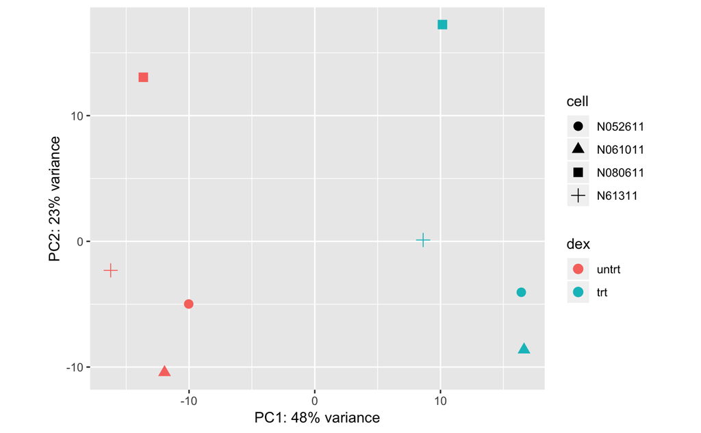

```r
percentVar <- round(100 * attr(pcaData, "percentVar"))
ggplot(pcaData, aes(x = PC1, y = PC2, color = dex, shape = cell)) +
  geom_point(size =3) +
  xlab(paste0("PC1: ", percentVar[1], "% variance")) +
  ylab(paste0("PC2: ", percentVar[2], "% variance")) +
  coord_fixed()
```

### Section 4.5: MDS plot

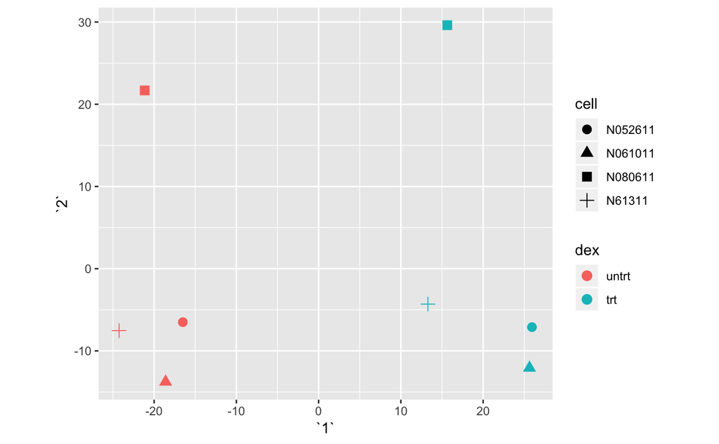

```r
mds <- as.data.frame(colData(vsd))  %>%
         cbind(cmdscale(sampleDistMatrix))
ggplot(mds, aes(x = `1`, y = `2`, color = dex, shape = cell)) +
  geom_point(size = 3) + coord_fixed()
```

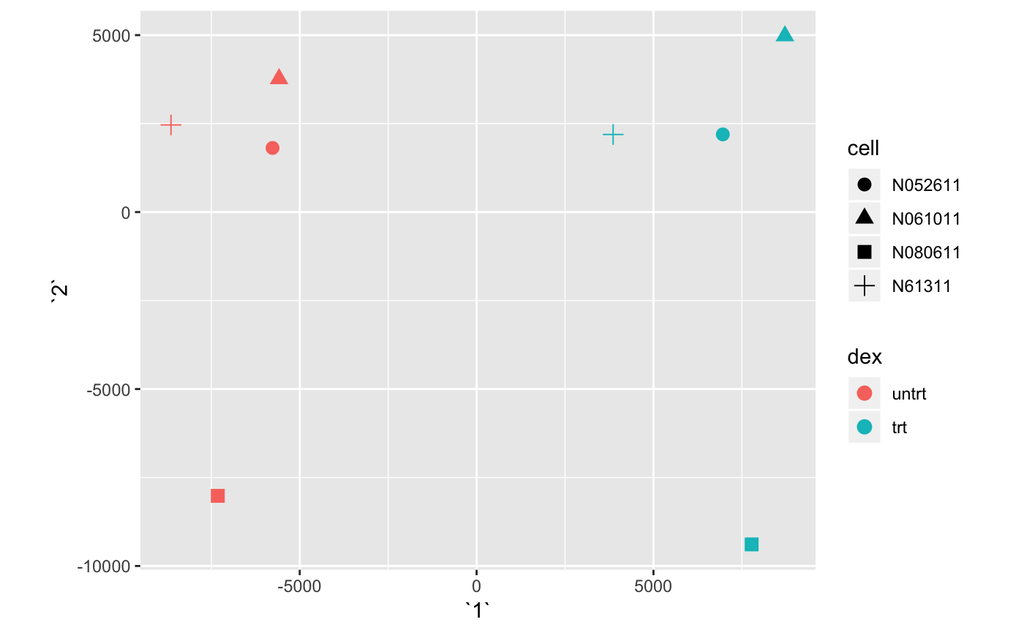

```r
mdsPois <- as.data.frame(colData(dds)) %>%
   cbind(cmdscale(samplePoisDistMatrix))
ggplot(mdsPois, aes(x = `1`, y = `2`, color = dex, shape = cell)) +
  geom_point(size = 3) + coord_fixed()
```

## Section 5: Differential expression analysis

### Section 5.1: Running the differential expression pipeline

```r
dds <- DESeq(dds)
```

### Section 5.2: Building the results table

```r
res <- results(dds)
res
```

```
log2 fold change (MLE): dex trt vs untrt
Wald test p-value: dex trt vs untrt
DataFrame with 29391 rows and 6 columns
                         baseMean      log2FoldChange             lfcSE                stat
                        <numeric>           <numeric>         <numeric>           <numeric>
ENSG00000000003  708.602169691234  -0.381253887429316 0.100654430187038   -3.78775069036569
ENSG00000000419  520.297900552084   0.206812715390385 0.112218674572541    1.84294384315417
ENSG00000000457  237.163036796015  0.0379205923945968 0.143444716340173   0.264356843264061
ENSG00000000460  57.9326331250967 -0.0881676962637897 0.287141995230742  -0.307052600205483
ENSG00000000938 0.318098378392895     -1.378233965407  3.49987526565862   -0.39379516719652
...                           ...                 ...               ...                 ...
ENSG00000273485  1.28644765243289  -0.127098087720873  1.60042118107398 -0.0794153996609706
ENSG00000273486  15.4525365439045  -0.150988513292619 0.486499370223247  -0.310357058064294
ENSG00000273487   8.1632349843654    1.04640806907172 0.698967253900779    1.49707738557415
ENSG00000273488  8.58447903624707   0.107831134309983 0.638099483385527   0.168987966794565
ENSG00000273489 0.275899382507797    1.48372584344306  3.51394515550545   0.422239328669782
                              pvalue                padj
                           <numeric>           <numeric>
ENSG00000000003 0.000152017272634607 0.00128121723830778
ENSG00000000419   0.0653372100766968   0.196207903558091
ENSG00000000457    0.791504963002084   0.911194055629062
ENSG00000000460    0.758803335537906   0.894634203883442
ENSG00000000938    0.693732272741941                  NA
...                              ...                 ...
ENSG00000273485    0.936702220169112                  NA
ENSG00000273486    0.756289445616056   0.893661169189343
ENSG00000273487    0.134373123316846   0.329056883636817
ENSG00000273488    0.865806106383284    0.94518264611909
ENSG00000273489    0.672850337762335                  NA
```

```r
# equivalent to
res <- results(dds, contrast=c("dex","trt","untrt"))
mcols(res, use.names = TRUE)
```

```
DataFrame with 6 rows and 2 columns
                       type                               description
                <character>                               <character>
baseMean       intermediate mean of normalized counts for all samples
log2FoldChange      results  log2 fold change (MLE): dex trt vs untrt
lfcSE               results          standard error: dex trt vs untrt
stat                results          Wald statistic: dex trt vs untrt
pvalue              results       Wald test p-value: dex trt vs untrt
padj                results                      BH adjusted p-values
```

```r
summary(res)
```

```
out of 29391 with nonzero total read count
adjusted p-value < 0.1
LFC > 0 (up)       : 2607, 8.9%
LFC < 0 (down)     : 2218, 7.5%
outliers [1]       : 0, 0%
low counts [2]     : 11397, 39%
(mean count < 5)
[1] see 'cooksCutoff' argument of ?results
[2] see 'independentFiltering' argument of ?results
```

```r
res.05 <- results(dds, alpha = 0.05)
table(res.05$padj < 0.05)
```

```
FALSE  TRUE
12829  4026
```

```r
resLFC1 <- results(dds, lfcThreshold=1)
table(resLFC1$padj < 0.1)
```

```
FALSE  TRUE
20034   240
```

### Section 5.3: Other comparisons

```r
results(dds, contrast = c("cell", "N061011", "N61311"))
```

```
log2 fold change (MLE): cell N061011 vs N61311
Wald test p-value: cell N061011 vs N61311
DataFrame with 29391 rows and 6 columns
                         baseMean      log2FoldChange             lfcSE                stat
                        <numeric>           <numeric>         <numeric>           <numeric>
ENSG00000000003  708.602169691234   0.306326362739978 0.143530866244254     2.1342194244037
ENSG00000000419  520.297900552084 -0.0540467035087685 0.159716090785554  -0.338392351346335
ENSG00000000457  237.163036796015  0.0163084038114845  0.20302595697949   0.080326693463792
ENSG00000000460  57.9326331250967   0.279127044592995 0.400667397006202   0.696655247416285
ENSG00000000938 0.318098378392895                   0   4.9975798104491                   0
...                           ...                 ...               ...                 ...
ENSG00000273485  1.28644765243289   -2.32141260766577  2.35291638140544  -0.986610755066082
ENSG00000273486  15.4525365439045 -0.0727157623832583 0.711890912073144  -0.102144529660448
ENSG00000273487   8.1632349843654 -0.0269346906402043  1.00507452886325 -0.0267986998642455
ENSG00000273488  8.58447903624707    1.09584759066512 0.898948246150508    1.21903301481234
ENSG00000273489 0.275899382507797                   0   4.9975798104491                   0
                            pvalue              padj
                         <numeric>         <numeric>
ENSG00000000003 0.0328248233823354 0.214730145872796
ENSG00000000419  0.735067537267948 0.935493501438616
ENSG00000000457  0.935977428491716 0.989390053166377
ENSG00000000460  0.486018572065081 0.846163823311993
ENSG00000000938                  1                NA
...                            ...               ...
ENSG00000273485  0.323833495704889                NA
ENSG00000273486  0.918641956272754 0.985420987200884
ENSG00000273487  0.978620290204838                NA
ENSG00000273488  0.222831662001976                NA
ENSG00000273489                  1                NA
```

### Section 5.4: Multiple testing

```r
sum(res$pvalue < 0.05, na.rm=TRUE)
```

```
[1] 5677
```

```r
sum(!is.na(res$pvalue))
```

```
[1] 29391
```

```r
sum(res$padj < 0.1, na.rm=TRUE)
```

```
[1] 4825
```

```r
resSig <- subset(res, padj < 0.1)
head(resSig[ order(resSig$log2FoldChange), ])
```

```
log2 fold change (MLE): dex trt vs untrt
Wald test p-value: dex trt vs untrt
DataFrame with 6 rows and 6 columns
                        baseMean    log2FoldChange             lfcSE              stat
                       <numeric>         <numeric>         <numeric>         <numeric>
ENSG00000128285 6.62474139908411 -5.32590514755406  1.25781646244798 -4.23424665406963
ENSG00000267339 26.2335725682209 -4.61155039131948 0.673094468700225 -6.85126769831371
ENSG00000019186 14.0876049307722 -4.32590664693342 0.857767767163719 -5.04321427376246
ENSG00000183454 5.80417114112773 -4.26407747502168  1.16687734166995 -3.65426366829546
ENSG00000146006 46.8075965458274  -4.2118502375277 0.528851947804937 -7.96413864978561
ENSG00000141469 53.4365283575179 -4.12478447879794   1.1297976633824 -3.65090547846338
                              pvalue                 padj
                           <numeric>            <numeric>
ENSG00000128285 2.29319143028289e-05  0.00023755720550668
ENSG00000267339 7.31983899180918e-12 2.04841652906088e-10
ENSG00000019186  4.5777613182453e-07 6.60462531203733e-06
ENSG00000183454 0.000257921111014126  0.00204722065415288
ENSG00000146006 1.66378621897173e-15 7.14247557421898e-14
ENSG00000141469 0.000261317404823323  0.00206960624224951
```

```r
head(resSig[ order(resSig$log2FoldChange, decreasing = TRUE), ])
```

```
log2 fold change (MLE): dex trt vs untrt
Wald test p-value: dex trt vs untrt
DataFrame with 6 rows and 6 columns
                        baseMean   log2FoldChange             lfcSE             stat
                       <numeric>        <numeric>         <numeric>        <numeric>
ENSG00000179593 67.2430476358842 9.50597241247416  1.05450220396068 9.01465390662063
ENSG00000109906 385.071028862516 7.35262793318718 0.536390220039323 13.7076099796304
ENSG00000250978 56.3181939282226  6.3273837397078 0.677797382672816 9.33521418267579
ENSG00000132518 5.65465445433956 5.88511165460784  1.32404324478884 4.44480320244103
ENSG00000127954 286.384119280247 5.20716032804828 0.493082760580173 10.5604185429671
ENSG00000249364 8.83906075961539 5.09810727071616  1.15961389777208 4.39638338287508
                              pvalue                 padj
                           <numeric>            <numeric>
ENSG00000179593 1.97493059046227e-19 1.25129933256261e-17
ENSG00000109906 9.14198752722158e-43 2.25343730910719e-40
ENSG00000250978 1.00787266738981e-20 7.19669078452868e-19
ENSG00000132518 8.79723586811642e-06 9.98722159059223e-05
ENSG00000127954 4.54630170772714e-26 5.04976252647174e-24
ENSG00000249364 1.10069452799683e-05 0.000122258625535648
```

## Section 6: Plotting results

### Section 6.1: Counts plot

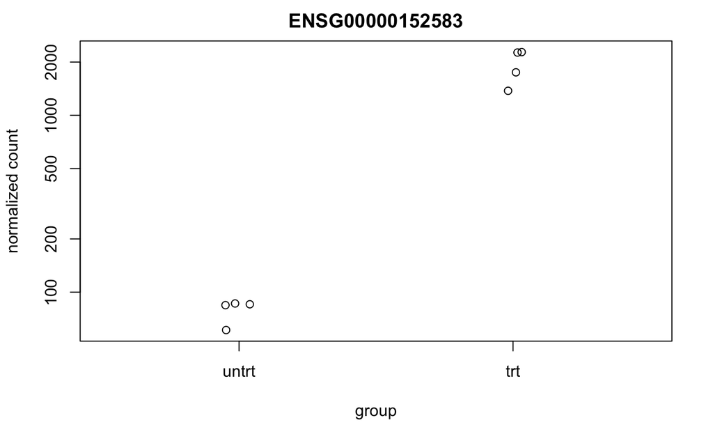

```r
topGene <- rownames(res)[which.min(res$padj)]
plotCounts(dds, gene = topGene, intgroup=c("dex"))
```

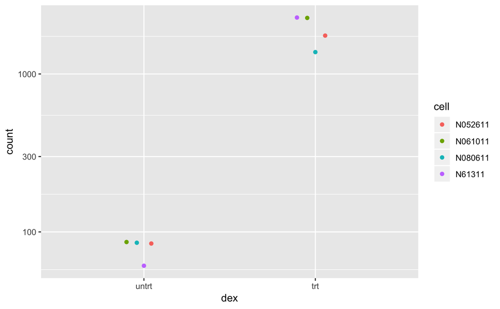

```r
library("ggbeeswarm")
geneCounts <- plotCounts(dds, gene = topGene, intgroup = c("dex","cell"),
                         returnData = TRUE)
ggplot(geneCounts, aes(x = dex, y = count, color = cell)) +
  scale_y_log10() +  geom_beeswarm(cex = 3)
```

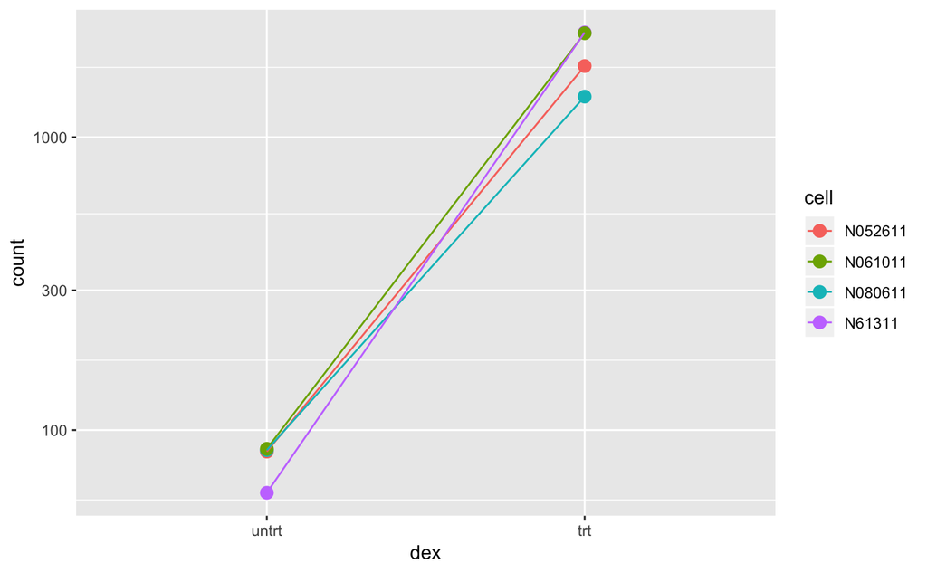

```r
ggplot(geneCounts, aes(x = dex, y = count, color = cell, group = cell)) +
  scale_y_log10() + geom_point(size = 3) + geom_line()
```

### Section 6.2: MA-plot

```r
library("apeglm")
resultsNames(dds)
```

```
[1] "Intercept"               "cell_N061011_vs_N052611" "cell_N080611_vs_N052611"
[4] "cell_N61311_vs_N052611"  "dex_trt_vs_untrt"
```

```r
res <- lfcShrink(dds, coef="dex_trt_vs_untrt", type="apeglm")
```

```
using 'apeglm' for LFC shrinkage. If used in published research, please cite:
    Zhu, A., Ibrahim, J.G., Love, M.I. (2018) Heavy-tailed prior distributions for
    sequence count data: removing the noise and preserving large differences.
    Bioinformatics. https://doi.org/10.1093/bioinformatics/bty895
```

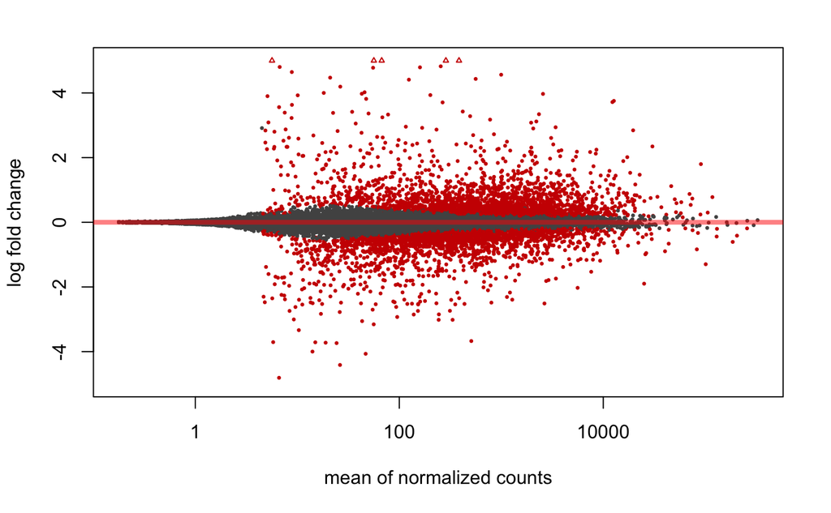

```r
plotMA(res, ylim = c(-5, 5))
```

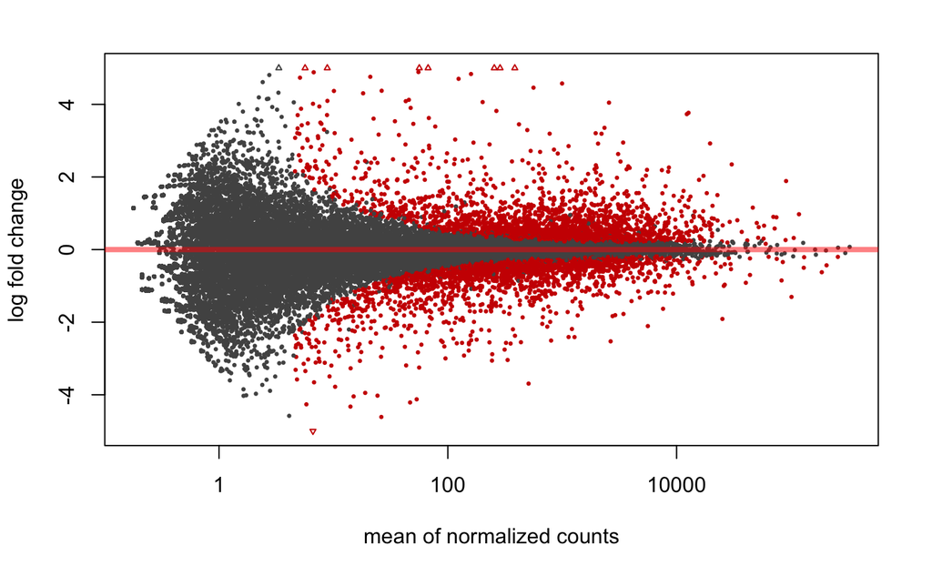

```r
res.noshr <- results(dds, name="dex_trt_vs_untrt")
plotMA(res.noshr, ylim = c(-5, 5))
```

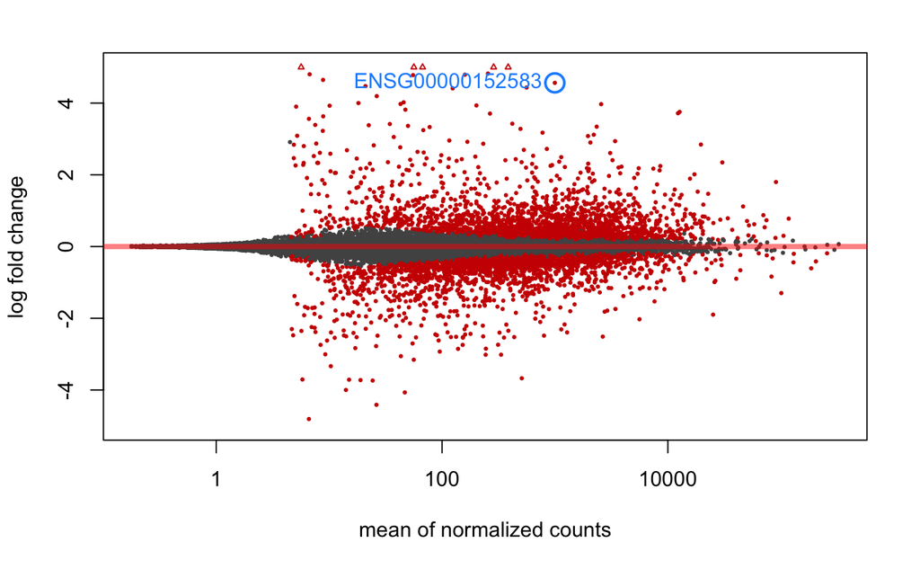

```r
plotMA(res, ylim = c(-5,5))
topGene <- rownames(res)[which.min(res$padj)]
with(res[topGene, ], {
  points(baseMean, log2FoldChange, col="dodgerblue", cex=2, lwd=2)
  text(baseMean, log2FoldChange, topGene, pos=2, col="dodgerblue")
})
```

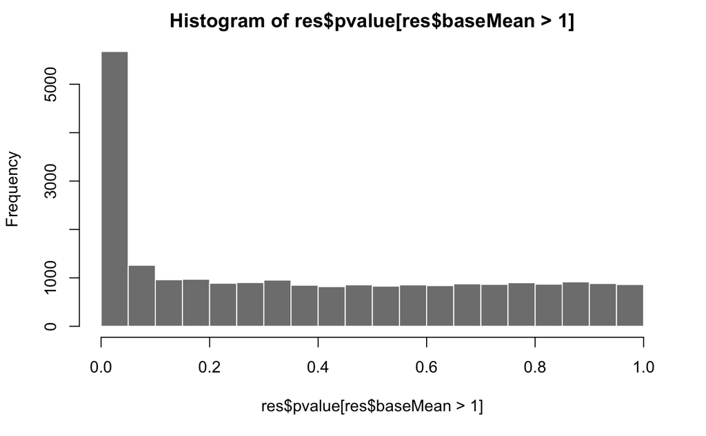

```r
hist(res$pvalue[res$baseMean > 1], breaks = 0:20/20,
     col = "grey50", border = "white")
```

### Section 6.3: Gene clustering

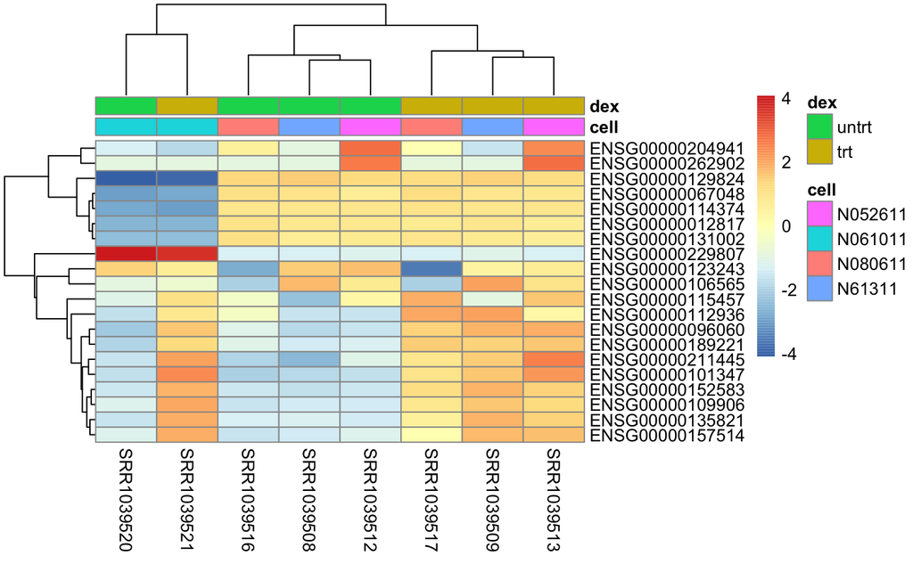

```r
library("genefilter")
topVarGenes <- head(order(rowVars(assay(vsd)), decreasing = TRUE), 20)
mat  <- assay(vsd)[ topVarGenes, ]
mat  <- mat - rowMeans(mat)
anno <- as.data.frame(colData(vsd)[, c("cell","dex")])
pheatmap(mat, annotation_col = anno)
```

### Section 6.4: Independent filtering

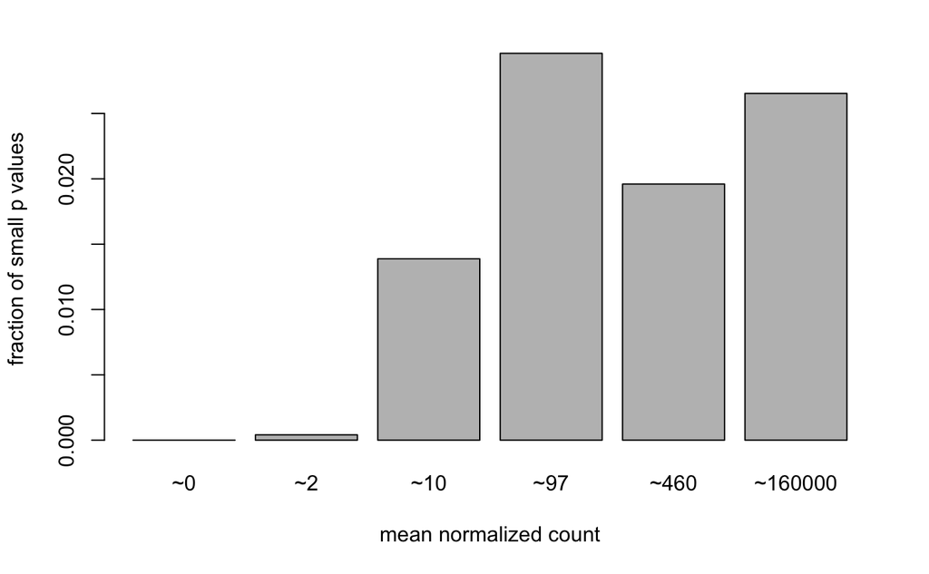

```r
qs <- c(0, quantile(resLFC1$baseMean[resLFC1$baseMean > 0], 0:6/6))
bins <- cut(resLFC1$baseMean, qs)
levels(bins) <- paste0("~", round(signif((qs[-1] + qs[-length(qs)])/2, 2)))
fractionSig <- tapply(resLFC1$pvalue, bins, function(p)
                          mean(p < .05, na.rm = TRUE))
barplot(fractionSig, xlab = "mean normalized count",
                     ylab = "fraction of small p values")
```

## Section 7: Annotating and exporting results

```r
library("AnnotationDbi")
library("org.Hs.eg.db")
columns(org.Hs.eg.db)
```

```
 [1] "ACCNUM"       "ALIAS"        "ENSEMBL"      "ENSEMBLPROT"  "ENSEMBLTRANS" "ENTREZID"
 [7] "ENZYME"       "EVIDENCE"     "EVIDENCEALL"  "GENENAME"     "GO"           "GOALL"
[13] "IPI"          "MAP"          "OMIM"         "ONTOLOGY"     "ONTOLOGYALL"  "PATH"
[19] "PFAM"         "PMID"         "PROSITE"      "REFSEQ"       "SYMBOL"       "UCSCKG"
[25] "UNIGENE"      "UNIPROT"
```

```r
res$symbol <- mapIds(org.Hs.eg.db,
                     keys=row.names(res),
                     column="SYMBOL",
                     keytype="ENSEMBL",
                     multiVals="first")
res$entrez <- mapIds(org.Hs.eg.db,
                     keys=row.names(res),
                     column="ENTREZID",
                     keytype="ENSEMBL",
                     multiVals="first")
resOrdered <- res[order(res$pvalue),]
head(resOrdered)
```

```
log2 fold change (MAP): dex trt vs untrt
Wald test p-value: dex trt vs untrt
DataFrame with 6 rows and 7 columns
                        baseMean   log2FoldChange             lfcSE                pvalue
                       <numeric>        <numeric>         <numeric>             <numeric>
ENSG00000152583 997.439773207048 4.56334706475901 0.185619897835832 2.22231974839155e-136
ENSG00000165995 495.092906698546 3.28035231082946 0.133330866932628  7.8397572087114e-135
ENSG00000120129 3409.02937530956 2.93799351420719  0.12202777083291 3.66732005915504e-130
ENSG00000101347 12703.3870621821 3.75352539563574  0.15705353372166 9.56353875785341e-130
ENSG00000189221 2341.76725275591  3.3421864346776 0.143093947297795 1.09937074996403e-123
ENSG00000211445 12285.6151498691  3.7169519696876 0.167889677029247 4.61813781939102e-112
                                 padj      symbol      entrez
                            <numeric> <character> <character>
ENSG00000152583 3.99884215525576e-132     SPARCL1        8404
ENSG00000165995 7.05342956067765e-131      CACNB2         783
ENSG00000120129 2.19965857148119e-126       DUSP1        1843
ENSG00000101347 4.30215791022035e-126      SAMHD1       25939
ENSG00000189221 3.95641545497056e-120        MAOA        4128
ENSG00000211445 1.38497953203537e-108        GPX3        2878
```

### Section 7.1: Exporting results

```r
resOrderedDF <- as.data.frame(resOrdered)[1:100, ]
write.csv(resOrderedDF, file = "results.csv")
library("ReportingTools")
htmlRep <- HTMLReport(shortName="report", title="My report",
                      reportDirectory="./report")
publish(resOrderedDF, htmlRep)
url <- finish(htmlRep)
browseURL(url)
```

## GLUE SECTION: Generating gene sets for GO analysis

We’ll be starting from the resLFC1 (|log2foldchange| > 1) results object from section 5.2, annotating it, and filtering for adjusted p-value < 0.1

```r
resLFC1
```

```
log2 fold change (MLE): dex trt vs untrt
Wald test p-value: dex trt vs untrt
DataFrame with 29391 rows and 6 columns
                         baseMean      log2FoldChange             lfcSE               stat
                        <numeric>           <numeric>         <numeric>          <numeric>
ENSG00000000003  708.602169691234  -0.381253887429316 0.100654430187038                  0
ENSG00000000419  520.297900552084   0.206812715390385 0.112218674572541                  0
ENSG00000000457  237.163036796015  0.0379205923945968 0.143444716340173                  0
ENSG00000000460  57.9326331250967 -0.0881676962637897 0.287141995230742                  0
ENSG00000000938 0.318098378392895     -1.378233965407  3.49987526565862 -0.108070698724122
...                           ...                 ...               ...                ...
ENSG00000273485  1.28644765243289  -0.127098087720873  1.60042118107398                  0
ENSG00000273486  15.4525365439045  -0.150988513292619 0.486499370223247                  0
ENSG00000273487   8.1632349843654    1.04640806907172 0.698967253900779 0.0663951977903521
ENSG00000273488  8.58447903624707   0.107831134309983 0.638099483385527                  0
ENSG00000273489 0.275899382507797    1.48372584344306  3.51394515550545   0.13765890531478
                           pvalue      padj
                        <numeric> <numeric>
ENSG00000000003                 1         1
ENSG00000000419                 1         1
ENSG00000000457                 1         1
ENSG00000000460                 1         1
ENSG00000000938 0.913939611026568        NA
...                           ...       ...
ENSG00000273485                 1        NA
ENSG00000273486                 1         1
ENSG00000273487 0.947063193376693         1
ENSG00000273488                 1         1
ENSG00000273489 0.890509998916736        NA
```

```r
# attach the gene symbols and entrez IDs to resLFC1 as in Section 7
resLFC1$symbol <- mapIds(org.Hs.eg.db,
                     keys=row.names(res),
                     column="SYMBOL",
                     keytype="ENSEMBL",
                     multiVals="first")
resLFC1$entrez <- mapIds(org.Hs.eg.db,
                     keys=row.names(res),
                     column="ENTREZID",
                     keytype="ENSEMBL",
                     multiVals="first")
# restrict by the padj <0.1 filter to the resLFC1 results
resLFC1Sig <- subset(resLFC1, padj < 0.1)
resLFC1Sig
```

```
log2 fold change (MLE): dex trt vs untrt
Wald test p-value: dex trt vs untrt
DataFrame with 240 rows and 8 columns
                        baseMean    log2FoldChange             lfcSE              stat
                       <numeric>         <numeric>         <numeric>         <numeric>
ENSG00000013293 244.497326184804  -2.8829065116048 0.218489771099364 -8.61782454222308
ENSG00000013297 3431.57264316715 -1.77433844122915 0.172997903370307 -4.47599899272566
ENSG00000016391 92.1114413835648 -2.00741601401991   0.2638400017013 -3.81828383688547
ENSG00000019186 14.0876049307722 -4.32590664693342 0.857767767163719 -3.87739755940097
ENSG00000025423  169.20409821807 -1.99290326518309 0.242715349830197  -4.0908136460167
...                          ...               ...               ...               ...
ENSG00000261685 48.4467108124499  2.27472678279414  0.38362041227696  3.32288570159253
ENSG00000264868 18.1834296019139  4.30413861007445   0.7765396928022  4.25495134466498
ENSG00000267339 26.2335725682209 -4.61155039131948 0.673094468700225 -5.36559214086775
ENSG00000268913 72.8570574700598  2.52640347224013 0.290781219267448  5.24931932015942
ENSG00000272841 114.903469824879 -2.01735830233187 0.240117530232877 -4.23691806818598
                              pvalue                 padj      symbol      entrez
                           <numeric>            <numeric> <character> <character>
ENSG00000013293 6.82381372143873e-18 3.29395236639164e-15     SLC7A14       57709
ENSG00000013297 7.60548429440116e-06 0.000945972936102387      CLDN11        5010
ENSG00000016391 0.000134383260914173   0.0139717242655074        CHDH       55349
ENSG00000019186 0.000105579758842025   0.0112069320982367     CYP24A1        1591
ENSG00000025423 4.29862439912849e-05  0.00488389206983629     HSD17B6        8630
...                              ...                  ...         ...         ...
ENSG00000261685 0.000890914109761598    0.078532142005681          NA          NA
ENSG00000264868 2.09094478354059e-05  0.00250839139298828          NA          NA
ENSG00000267339 8.06840778942165e-08 1.34081065182569e-05   LINC00906      148145
ENSG00000268913 1.52662249111039e-07 2.41802690506031e-05          NA          NA
ENSG00000272841 2.26608778735147e-05  0.00268670548542477          NA          NA
```

```r
resLFC1Sig_DF <- resLFC1Sig %>%
  as.data.frame() %>%
  tibble::rownames_to_column(var="Ensembl")
table(resLFC1Sig_DF$log2FoldChange>0)
```

```
FALSE  TRUE
   93   147
```

```r
# make the Up and Down subsets
resLFC1Sig_DFup <- subset(resLFC1Sig_DF, log2FoldChange > 0)
resLFC1Sig_DFdown <- subset(resLFC1Sig_DF, log2FoldChange < 0)
# write the up and down subsets using readr::write_tsv
library(readr)
write_tsv(resLFC1Sig_DFup, path = "resLFC1Sig_DFup.tsv")
write_tsv(resLFC1Sig_DFdown, path = "resLFC1Sig_DFdown.tsv")
```

### Section 8.1: Using SVA with DESeq2

### Section 8.2: Using RUV with DESeq2